# QTM150 Project 3: dplyr/ggplot2/Join

Renee Ngai

2025 Spring

## Dataset Introduction

County Health Rankings & Roadmaps (CHR&R), a program of the University of Wisconsin Population Health Institute, releases annual datasets that include county-level variables related to health disparities that draws attention to why there are differences in health within and across communities. The most recent data from 2024 contains most up-to-date county health and demographic measures.

We have a pair of datasets: *county_health_data.csv* and *county_demographic_data.csv* - The former dataset relates to health factors, including variables such as adult smoking rates, physical inactivity, alcohol impaired driving deaths, and poor mental health days. - The latter relates to demographic factors, including variables such as high school graduation rate, school segregation, voter turnout, and homicides.

## Part 1 : Import Dataset / Research Question

Please read in both datasets. Then, come up with one research question where visualizations (such as scatterplots, bargraphs, boxplots, etc.) can help to answer it.

- Must read in both datasets correctly and assign them to dataframe names
- The research question must involve *at least three variables*, with at least one variable coming from a different dataset than the others —i.e., all three variables *cannot* come from the same dataset.

```r
# Read in both datasets individually; save the joining process for the next part.
county_health_data<-read.csv("county_health_data.csv")
county_demographic_data<-read.csv("county_demographic_data.csv")

# Provide an overview of the datasets to examine variables and their types.
summary(county_health_data)
```

```
##  X5.digit.FIPS.Code State.Abbreviation     Name
##  Min.   : 1001      Length:3143        Length:3143
##  1st Qu.:18176      Class :character   Class :character
##  Median :29175      Mode  :character   Mode  :character
##  Mean   :30375
##  3rd Qu.:45080
##  Max.   :56045
##
##  Poor.or.Fair.Health.raw.value Poor.Physical.Health.Days.raw.value
##  Min.   :0.0840                Min.   :2.262
##  1st Qu.:0.1420                1st Qu.:3.398
##  Median :0.1690                Median :3.874
##  Mean   :0.1773                Mean   :3.896
##  3rd Qu.:0.2080                3rd Qu.:4.338
##  Max.   :0.3800                Max.   :6.837
##
##  Poor.Mental.Health.Days.raw.value Low.Birthweight.raw.value
##  Min.   :3.186                     Min.   :0.03053
##  1st Qu.:4.818                     1st Qu.:0.06934
##  Median :5.236                     Median :0.08065
##  Mean   :5.218                     Mean   :0.08364
##  3rd Qu.:5.632                     3rd Qu.:0.09301
##  Max.   :7.389                     Max.   :0.19178
##                                    NA's   :98
##  Adult.Smoking.raw.value Adult.Obesity.raw.value
##  Min.   :0.0700          Min.   :0.1740
##  1st Qu.:0.1640          1st Qu.:0.3510
##  Median :0.1870          Median :0.3770
##  Mean   :0.1904          Mean   :0.3735
##  3rd Qu.:0.2150          3rd Qu.:0.4030
##  Max.   :0.4300          Max.   :0.5250
##
##  Food.Environment.Index.raw.value Physical.Inactivity.raw.value
##  Min.   : 0.000                   Min.   :0.1200
##  1st Qu.: 6.900                   1st Qu.:0.2310
##  Median : 7.700                   Median :0.2630
##  Mean   : 7.543                   Mean   :0.2666
##  3rd Qu.: 8.400                   3rd Qu.:0.3010
##  Max.   :10.000                   Max.   :0.4700
##  NA's   :35
##  Access.to.Exercise.Opportunities.raw.value
##  Min.   :0.0000
##  1st Qu.:0.4720
##  Median :0.6395
##  Mean   :0.6164
##  3rd Qu.:0.7909
##  Max.   :1.0000
##  NA's   :45
##  Alcohol.Impaired.Driving.Deaths.raw.value
##  Min.   :0.0000
##  1st Qu.:0.1818
##  Median :0.2632
##  Mean   :0.2731
##  3rd Qu.:0.3379
##  Max.   :1.0000
##  NA's   :27
```

```r
summary(county_demographic_data)
```

```
##  X5.digit.FIPS.Code State.Abbreviation     Name
##  Min.   : 1001      Length:3143        Length:3143
##  1st Qu.:18176      Class :character   Class :character
##  Median :29175      Mode  :character   Mode  :character
##  Mean   :30375
##  3rd Qu.:45080
##  Max.   :56045
##
##  High.School.Graduation.raw.value Disconnected.Youth.raw.value
##  Min.   :0.1750                   Min.   :0.0145
##  1st Qu.:0.8547                   1st Qu.:0.0583
##  Median :0.8956                   Median :0.0813
##  Mean   :0.8840                   Mean   :0.0936
##  3rd Qu.:0.9268                   3rd Qu.:0.1124
##  Max.   :0.9950                   Max.   :0.5638
##  NA's   :676                      NA's   :1970
##  School.Segregation.raw.value School.Funding.Adequacy.raw.value
##  Min.   :0.00059              Min.   :-63405.9
##  1st Qu.:0.03346              1st Qu.: -4486.0
##  Median :0.05935              Median :  -914.5
##  Mean   :0.08301              Mean   : -1988.3
##  3rd Qu.:0.10805              3rd Qu.:  1865.2
##  Max.   :0.66924              Max.   : 32379.7
##  NA's   :221                  NA's   :84
##  Gender.Pay.Gap.raw.value Median.Household.Income.raw.value
##  Min.   :0.2587           Min.   : 28972
##  1st Qu.:0.7270           1st Qu.: 52472
##  Median :0.7803           Median : 60821
##  Mean   :0.7815           Mean   : 63268
##  3rd Qu.:0.8327           3rd Qu.: 70587
##  Max.   :1.7281           Max.   :167605
##  NA's   :6                NA's   :1
##  Children.Eligible.for.Free.or.Reduced.Price.Lunch.raw.value
##  Min.   :0.0269
##  1st Qu.:0.3735
##  Median :0.4973
##  Mean   :0.5187
##  3rd Qu.:0.6398
##  Max.   :1.0000
##  NA's   :542
##  Child.Care.Cost.Burden.raw.value Homicides.raw.value Voter.Turnout.raw.value
##  Min.   :0.05405                  Min.   : 0.6598     Min.   :0.1942
##  1st Qu.:0.23594                  1st Qu.: 3.5733     1st Qu.:0.5891
##  Median :0.27074                  Median : 5.8118     Median :0.6575
##  Mean   :0.27565                  Mean   : 7.6819     Mean   :0.6567
##  3rd Qu.:0.31071                  3rd Qu.: 9.5520     3rd Qu.:0.7260
##  Max.   :0.80475                  Max.   :49.9699     Max.   :1.0000
##  NA's   :1                        NA's   :1767        NA's   :31
##  Juvenile.Arrests.raw.value Homeownership.raw.value
##  Min.   :  0.000            Min.   :0.0000
##  1st Qu.:  9.117            1st Qu.:0.6837
##  Median : 15.454            Median :0.7404
##  Mean   : 18.195            Mean   :0.7271
##  3rd Qu.: 23.576            3rd Qu.:0.7848
##  Max.   :121.667            Max.   :0.9699
##  NA's   :1224
```

```r
# Explicitly state your RESEARCH QUESTION and the variables used in the research question (at least three variables).

#What is the relationship between median household income and the number of poor mental health days as sorted by different states?
```

## Part 2: Join/ Data Manipulation/ Visualization

Step1. Join - Must appropriately join the datasets and assign the joined dataset to a new dataframe name (HINT: use `X5.digit.FIPS.Code` as the key variable)

Step2. Manipulate the joined dataset - Must drop the missing values only in the variables of your choice (do not remove all missing values unrelated to your selected variables). - Must use *at least five* of these dplyr functions to further manipulate/summarize the data for ggplot: group_by, summarize, arrange, filter, select, count, and top_n (or equivalent) functions

Step3. Visualize the summarized/manipulated dataset - Must select the most suitable plot type to address the research question - Must have meaningful x-axis and y-axis titles - Must have an overall meaningful plot title - Must ensure the visualization represents *at least three variables of your choice* through aesthetic mapping or faceting - Must add a text annotation/label to a data point (or multiple ones) in the plot - If there is a legend in the plot, it must be properly labeled with correct capitalization

- One plot is sufficient, but additional, meaningful supplementary plots (with significantly different aesthetics or involving other variables of your choice) will earn extra points for the sake of encouraging more practice.
- While all three steps can be piped together into a single chained operation, it is not necessary. However, you must chain at least each step using the pipe operator (%>%).

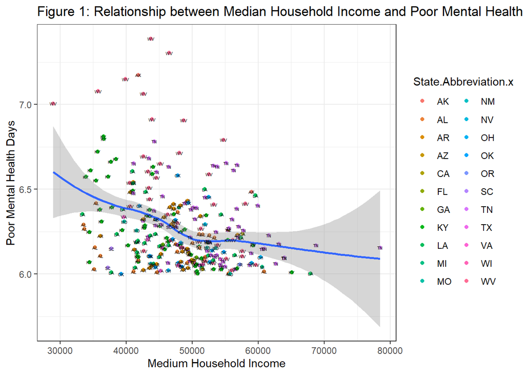

```r
# Write your dplyr code here to join the datasets (Step 1)

joined_county_data<-inner_join(county_health_data, county_demographic_data, by="X5.digit.FIPS.Code")

# Which JOIN was used and the justification for why it was used (Answer required)

#Inner join was used because both dataset have the common key variable of the X5.digit.FIPS.Code and all x and y observations should be kept in this situation.

# Write your dplyr code here to manipulate the data (Step 2)

new_data<-joined_county_data%>%
   drop_na(Median.Household.Income.raw.value, Poor.Mental.Health.Days.raw.value, State.Abbreviation.x)%>%
  group_by(Median.Household.Income.raw.value, Poor.Mental.Health.Days.raw.value)%>%
  arrange(Median.Household.Income.raw.value,Poor.Mental.Health.Days.raw.value)%>%
  filter(Median.Household.Income.raw.value>15000)%>%
  filter(Poor.Mental.Health.Days.raw.value>6)%>%
  select(High.School.Graduation.raw.value, Median.Household.Income.raw.value, Poor.Mental.Health.Days.raw.value, State.Abbreviation.x, Disconnected.Youth.raw.value)%>%
  top_n(50, High.School.Graduation.raw.value)


# Write your ggplot code here to answer the research question (Step 3)

ggplot(new_data, aes(x=Median.Household.Income.raw.value, y=Poor.Mental.Health.Days.raw.value))+
  geom_point(aes(color=State.Abbreviation.x))+
  geom_smooth()+
  geom_text(aes(label=State.Abbreviation.x), size=1.5)+
  labs(x="Medium Household Income",y="Poor Mental Health Days",title="Figure 1: Relationship between Median Household Income and Poor Mental Health Days")+
  theme_bw()
```

# Part 3: Interpretation

Supplemental Graphs for Extra Credit:

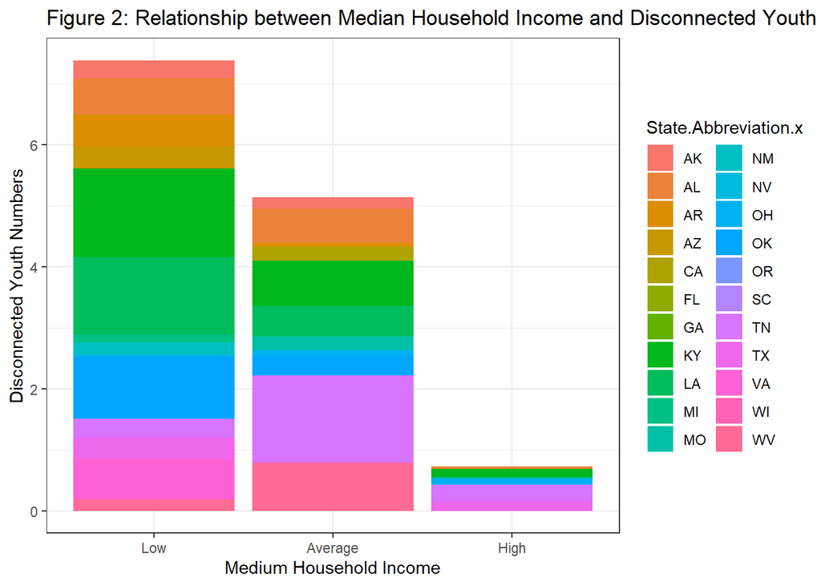

```r
new_data$Household_factor<-factor(new_data$Median.Household.Income.raw.value,
                   levels=c("Low", "Average","High"), ordered=T)

new_data$Household_factor[new_data$Median.Household.Income.raw.value<50000 & new_data$Median.Household.Income.raw.value>=0]<-"Low"
new_data$Household_factor[new_data$Median.Household.Income.raw.value<60000 & new_data$Median.Household.Income.raw.value>=50000]<-"Average"
new_data$Household_factor[new_data$Median.Household.Income.raw.value>60000]<-"High"

ggplot(new_data, aes(x=Household_factor, y=Disconnected.Youth.raw.value), na.rm=T)+
  geom_bar(stat="identity", aes(fill=State.Abbreviation.x))+
  labs(x="Medium Household Income",y="Disconnected Youth Numbers",title="Figure 2: Relationship between Median Household Income and Disconnected Youth")+
  theme_bw()
```

Supplemental Graph Interpretation

The graph shows a bar graph of the relationship between the household income in categories of three from Low, Average, to High and the number of disconnected youth through the disconnected youth raw value. The graph shows that in the low median household income categories, there are the highest number of disconnected youth while in the high median household income categories there are the lowest number of disconnected youth.